# Parquet to summary: cuplyr, DuckDB, dplyr and data.table

## Setup

### Machine and software

All numbers come from one machine: a 12th Gen Intel(R) Core(TM) i9-12900K with 24 logical CPUs and 31 GB of RAM, and a NVIDIA GeForce RTX 5070 with 12 GB of memory. The data directory is on `/dev/mapper/root` (device type `crypt`, file system `btrfs`). Versions: cuplyr 0.1.1.9000 (package code at commit a82772f, libcudf 25.12.00), DuckDB 2.0.0, dplyr 1.2.1, arrow 26.0.1, data.table 1.18.4, R 4.6.1. cuplyr is loaded from the checkout with `pkgload::load_all()`; nothing is installed.

### Provenance

The driver appends a row to `provenance.csv` for every step it runs: the benchmark code’s commit, whether `bench/` had uncommitted changes, the commit of the package code and whether it was modified, and the start and end of the step. The steps that take timings refuse to run with uncommitted changes in `bench/`. The 16 recorded steps ran between 10:13 and 11:56 on 2026-11-11, from benchmark commit 418f591 and package commit a82772f; no step ran with uncommitted changes, and every step ended ok. The timings are the 12 time steps (one size, table and cache each); 0 of them ran more than once, and 0 timing rows were superseded (`timings-superseded.csv` keeps any attempt that a re-run replaces).

| step | piece | started | minutes | benchmark commit | bench/ clean | package commit | package clean |
| --- | --- | --- | --- | --- | --- | --- | --- |
| check |  | 10:13:09 | 3.7 | 418f591 | TRUE | a82772f | TRUE |
| readers |  | 10:17:16 | 14.6 | 418f591 | TRUE | a82772f | TRUE |
| time | 1e6 narrow warm | 10:32:21 | 2.7 | 418f591 | TRUE | a82772f | TRUE |
| time | 1e6 narrow cold | 10:35:22 | 2.8 | 418f591 | TRUE | a82772f | TRUE |
| time | 1e6 wide warm | 10:38:31 | 2.7 | 418f591 | TRUE | a82772f | TRUE |
| time | 1e6 wide cold | 10:41:32 | 2.8 | 418f591 | TRUE | a82772f | TRUE |
| time | 1e7 narrow warm | 10:44:41 | 3.6 | 418f591 | TRUE | a82772f | TRUE |
| time | 1e7 narrow cold | 10:48:39 | 3.7 | 418f591 | TRUE | a82772f | TRUE |
| time | 1e7 wide warm | 10:52:45 | 3.6 | 418f591 | TRUE | a82772f | TRUE |
| time | 1e7 wide cold | 10:56:44 | 3.8 | 418f591 | TRUE | a82772f | TRUE |
| time | 1e8 narrow warm | 11:00:53 | 12.4 | 418f591 | TRUE | a82772f | TRUE |
| time | 1e8 narrow cold | 11:13:40 | 12.7 | 418f591 | TRUE | a82772f | TRUE |
| time | 1e8 wide warm | 11:26:46 | 12.2 | 418f591 | TRUE | a82772f | TRUE |
| time | 1e8 wide cold | 11:39:18 | 12.6 | 418f591 | TRUE | a82772f | TRUE |
| first |  | 11:52:18 | 1.5 | 418f591 | TRUE | a82772f | TRUE |
| probe |  | 11:54:07 | 2.4 | 418f591 | TRUE | a82772f | TRUE |

### Data

The data are synthetic and seeded, written once with arrow (`ParquetFileWriter`, snappy compression: the codec in `files.csv` is snappy, row groups of 1,048,576 rows, the last one shorter). The narrow table has 8 columns: `day` (a Date, sorted ascending, like an event log), `store`, `product` and `qty` (integers), `price` and `discount` (doubles; `discount` has missing values), `channel` and `category` (strings). The wide table has the same columns with identical values plus the filler columns `x01` to `x32` (integers and doubles with few distinct values), 40 columns in all; a pipeline reads at most 6 of them. A dimension file `stores.parquet` maps `store` to `region`.

| table | rows | size in MB | row groups | codec | columns |
| --- | --- | --- | --- | --- | --- |
| narrow | 1e6 | 8 | 1 | SNAPPY | 8 |
| narrow | 1e7 | 77 | 10 | SNAPPY | 8 |
| narrow | 1e8 | 773 | 96 | SNAPPY | 8 |
| wide | 1e6 | 36 | 1 | SNAPPY | 40 |
| wide | 1e7 | 359 | 10 | SNAPPY | 40 |
| wide | 1e8 | 3,593 | 96 | SNAPPY | 40 |

### Pipelines

Three pipelines, each with two filters, make six variants (`p1_push`, `p1_nopush`, and so on).

- `p1`: filter, mutate, group by store and channel, summarise (4000 groups)
- `p2`: filter, mutate, join to the store dimension, group by region and channel, summarise (40 groups)
- `p3`: filter, mutate, group by product, sum the revenue, keep the top 10 (ties kept)

The **push** filter is on the Date and the integer column (`day` on or after 2024-01-01 and `qty` at least 2). cuplyr moves such filters into the parquet scan (they are pushed), so row groups whose statistics rule them out are never read. The **nopush** filter is on the double and the string column (`price` at least 150 and `channel` not phone); cuplyr never pushes those. The two keep a similar share of the rows (19% and 19%), but they are not the same amount of work for an engine, and the CPU engines show it (see the pushdown section). Because `day` is sorted, the pushed date filter can skip whole row groups; how many row groups each pushed filter really skipped is in the pushdown table below.

### Engines and their code

Each engine is written the way its users write it, and reads only the columns the variant needs.

**cuplyr** reads with `read_parquet_gpu()`, which is lazy by default: the projection and the pushed filter go into the scan. The verbs build a plan (the function below), and `collect()` runs it and brings the summary to R. The option `cuplyr.fallback = "error"` makes a CPU fallback an error, so every number is a GPU number.

```r
function(variant, fact, dim) {
  k <- pp_constants()
  day_from <- k$day_from; qty_min <- k$qty_min
  price_min <- k$price_min; channel_drop <- k$channel_drop; topn <- k$top_n
  x <- cuplyr::read_parquet_gpu(fact)
  x <- if (grepl("_push$", variant)) {
    dplyr::filter(x, day >= day_from, qty >= qty_min)
  } else {
    dplyr::filter(x, price >= price_min, channel != channel_drop)
  }
  x <- dplyr::mutate(x, revenue = price * qty * (1 - discount))
  switch(pp_pipeline_of(variant),
    p1 = x |>
      dplyr::group_by(store, channel) |>
      dplyr::summarise(n = dplyr::n(), revenue = sum(revenue, na.rm = TRUE),
                       avg_price = mean(price), max_qty = max(qty), .groups = "drop"),
    p2 = x |>
      dplyr::inner_join(cuplyr::read_parquet_gpu(dim), by = "store") |>
      dplyr::group_by(region, channel) |>
      dplyr::summarise(n = dplyr::n(), revenue = sum(revenue, na.rm = TRUE),
                       avg_price = mean(price), max_qty = max(qty), .groups = "drop"),
    p3 = x |>
      dplyr::group_by(product) |>
      dplyr::summarise(revenue = sum(revenue, na.rm = TRUE), n = dplyr::n()) |>
      dplyr::slice_max(revenue, n = topn)
  )
}
```

**DuckDB** keeps one in-memory connection per process (`duckdb(shared_home = FALSE)`), opened before timing like a package load. The query is SQL over `read_parquet('<path>')` with explicit columns, fetched with `dbGetQuery()`. It is SQL rather than dbplyr or duckplyr because that is what a DuckDB user writes. Three of the six queries:

```sql
SELECT store, channel, count(*) AS n, coalesce(sum(price * qty * (1 - discount)), 0) AS revenue, avg(price) AS avg_price, max(qty) AS max_qty
FROM read_parquet('<fact>.parquet')
WHERE day >= DATE '2024-01-01' AND qty >= 2
GROUP BY store, channel
```

```sql
SELECT s.region AS region, f.channel AS channel, count(*) AS n, coalesce(sum(price * qty * (1 - discount)), 0) AS revenue, avg(price) AS avg_price, max(qty) AS max_qty
FROM read_parquet('<fact>.parquet') AS f JOIN read_parquet('<stores>.parquet') AS s ON f.store = s.store
WHERE price >= 150 AND channel <> 'phone'
GROUP BY s.region, f.channel
```

```sql
SELECT product, coalesce(sum(price * qty * (1 - discount)), 0) AS revenue, count(*) AS n
FROM read_parquet('<fact>.parquet')
WHERE day >= DATE '2024-01-01' AND qty >= 2
GROUP BY product
QUALIFY rank() OVER (ORDER BY revenue DESC) <= 10
```

**dplyr** reads with `arrow::read_parquet(path, col_select = cols)` and runs the same verbs on the tibble.

```r
function(variant, fact, dim) {
  k <- pp_constants()
  day_from <- k$day_from; qty_min <- k$qty_min
  price_min <- k$price_min; channel_drop <- k$channel_drop; topn <- k$top_n
  x <- pp_read_arrow(fact, pp_columns(variant))
  x <- if (grepl("_push$", variant)) {
    dplyr::filter(x, day >= day_from, qty >= qty_min)
  } else {
    dplyr::filter(x, price >= price_min, channel != channel_drop)
  }
  x <- dplyr::mutate(x, revenue = price * qty * (1 - discount))
  switch(pp_pipeline_of(variant),
    p1 = x |>
      dplyr::group_by(store, channel) |>
      dplyr::summarise(n = dplyr::n(), revenue = sum(revenue, na.rm = TRUE),
                       avg_price = mean(price), max_qty = max(qty), .groups = "drop"),
    p2 = x |>
      dplyr::inner_join(pp_read_arrow(dim, c("store", "region")), by = "store") |>
      dplyr::group_by(region, channel) |>
      dplyr::summarise(n = dplyr::n(), revenue = sum(revenue, na.rm = TRUE),
                       avg_price = mean(price), max_qty = max(qty), .groups = "drop"),
    p3 = x |>
      dplyr::group_by(product) |>
      dplyr::summarise(revenue = sum(revenue, na.rm = TRUE), n = dplyr::n()) |>
      dplyr::slice_max(revenue, n = topn)
  )
}
```

**data.table** uses the same reader, then `setDT()` and data.table syntax. Two idioms were timed on one variant of each pipeline, in every table and size (forms.csv): a single call (the filter in `i`, the arithmetic inside `j`) and a stepwise form (filter, then `:=`, then aggregate). The single call was faster in 3 of 18 cells; the benchmark uses the stepwise form. The join pipeline joins the filtered facts to the dimension first (a keyed `data.table` join), so its result is a new table either way: in its 6 cells the stepwise time is 0.98 to 1.01 times the single-call time (the stepwise form was faster in 4), so the choice hardly matters there.

```r
function(variant, fact, dim, form = pp_constants()$dt_form) {
  k <- pp_constants()
  day_from <- k$day_from; qty_min <- k$qty_min
  price_min <- k$price_min; channel_drop <- k$channel_drop; topn <- k$top_n
  DT <- data.table::setDT(pp_read_arrow(fact, pp_columns(variant)))
  keep <- if (grepl("_push$", variant)) {
    DT$day >= day_from & DT$qty >= qty_min
  } else {
    DT$price >= price_min & DT$channel != channel_drop
  }
  pipe <- pp_pipeline_of(variant)
  by <- switch(pipe, p1 = c("store", "channel"), p2 = c("region", "channel"), p3 = "product")
  joined <- NULL
  if (pipe == "p2") {
    stores <- data.table::setDT(pp_read_arrow(dim, c("store", "region")))
    joined <- stores[DT[keep], on = "store", nomatch = NULL]
  }
  if (form == "single") {
    res <- if (pipe == "p2") {
      joined[, .(n = .N, revenue = sum(price * qty * (1 - discount), na.rm = TRUE),
                 avg_price = mean(price), max_qty = max(qty)), by = by]
    } else if (pipe == "p3") {
      DT[keep, .(revenue = sum(price * qty * (1 - discount), na.rm = TRUE), n = .N), by = by]
    } else {
      DT[keep, .(n = .N, revenue = sum(price * qty * (1 - discount), na.rm = TRUE),
                 avg_price = mean(price), max_qty = max(qty)), by = by]
    }
  } else {
    x <- if (pipe == "p2") joined else DT[keep]
    x[, revenue := price * qty * (1 - discount)]
    res <- if (pipe == "p3") {
      x[, .(revenue = sum(revenue, na.rm = TRUE), n = .N), by = by]
    } else {
      x[, .(n = .N, revenue = sum(revenue, na.rm = TRUE),
            avg_price = mean(price), max_qty = max(qty)), by = by]
    }
  }
  if (pipe == "p3") res <- res[data.table::frank(-revenue, ties.method = "min") <= topn]
  res
}
```

None of the results is sorted inside the timed region (dplyr’s `summarise()` sorts, DuckDB does not); the comparison sorts them.

### Threads and other settings

Every engine runs at its default thread count, read back from the running engine: DuckDB runs 24 threads, arrow 24 CPU and 8 I/O threads (dplyr and data.table both read with it), data.table 12 threads, and cuplyr runs the query on the GPU (1 device). That does not make cuplyr’s process idle on the CPU: its own CPU time (user and system, all threads) is a share of all 24 logical CPUs; multiplied by 24 it is 1 core at the median over its timed calls and 2 cores at the median for 1e8 rows with a warm cache (the highest single call: 2.6 cores). The medians for the other engines over all their timed calls are duckdb 2.3 cores, dplyr 1.1 cores and data.table 1.4 cores. What the CPU time is spent on in cuplyr is not examined here.

The settings that bear on what a timing means were read back from the running engines into `threads.csv` (the machine and version rows are in the text above):

| engine | setting | value | step |
| --- | --- | --- | --- |
| cuplyr | gpu_devices | 1 | time |
| cuplyr | debug_stream_pool | set (1) | time |
| duckdb | threads | 24 | time |
| duckdb | cache_local_files | FALSE | time |
| duckdb | enable_external_file_cache | TRUE | time |
| dplyr | arrow_cpu | 24 | time |
| dplyr | arrow_io | 8 | time |
| data.table | threads | 12 | time |
| harness | busy_max | 0.15 | time |
| harness | warmups | 2 | time |

DuckDB’s `cache_local_files` is FALSE and `enable_external_file_cache` is TRUE, so with these settings DuckDB keeps no copy of a local file between queries and warm and cold mean the operating system’s page cache for it too. libcudf’s debug stream pool, which cuplyr’s `.onLoad` switches on by default (`LIBCUDF_USE_DEBUG_STREAM_POOL`), read back as set (1) in the timing process.

### The parquet reader of dplyr and data.table

dplyr and data.table read with arrow. The `readers` step timed `arrow::read_parquet(path, col_select = cols)` and `nanoparquet::read_parquet(path, col_select = cols)` on the columns of the first variant, on every table and size with a warm cache: arrow is faster in 6 of 6 cells (a table and a size each); nanoparquet takes 1.1 to 12.1 times arrow’s time. The reader the code uses is the faster one in every cell.

### How the calls were timed

The shares during the timed calls, by engine and cache state (median and highest single call, as a share of all 24 logical CPUs):

| engine | cache | calls | foreign (median / highest) | kernel (median / highest) | own CPU as cores (median / highest) |
| --- | --- | --- | --- | --- | --- |
| cuplyr | warm | 360 | 0.0% / 12.6% | 0.0% / 4.6% | 1.1 / 2.6 |
| cuplyr | cold | 360 | 0.1% / 9.8% | 1.5% / 10.2% | 0.8 / 2.1 |
| duckdb | warm | 360 | 0.1% / 6.2% | 0.1% / 8.2% | 2.4 / 22.0 |
| duckdb | cold | 360 | 0.0% / 8.1% | 1.3% / 26.0% | 1.9 / 18.0 |
| dplyr | warm | 360 | 0.1% / 6.2% | 0.1% / 1.9% | 1.1 / 1.5 |
| dplyr | cold | 360 | 0.1% / 5.4% | 0.2% / 3.7% | 1.1 / 1.5 |
| data.table | warm | 360 | 0.1% / 7.9% | 0.1% / 4.3% | 1.5 / 2.7 |
| data.table | cold | 360 | 0.1% / 7.9% | 0.3% / 2.8% | 1.3 / 2.6 |

The foreign share is small for every engine and cache state, well below the limit. The median kernel share is higher on a cold cache than on a warm one for cuplyr, duckdb, dplyr and data.table, and the highest single kernel share is 26.0% (duckdb, cold cache, 1e8 rows). The data do not say what runs in the kernel; reading the files from the storage described above is a candidate (not tested here).

## Correctness

144 of the 144 results (engine, variant, table and size) equal the reference: keys exactly, measures within a relative tolerance of 1e-09. The reference is the first engine that ran of dplyr, data.table and DuckDB, in that order (it was: dplyr in 36 cells). Only cells that passed were timed.

|  | ok |
| --- | --- |
| cuplyr | 36 |
| duckdb | 36 |
| dplyr | 36 |
| data.table | 36 |

No engine gave a wrong result or an error in any cell.

## Results

Each table gives the median in seconds of the quiet reps, the interquartile range in brackets, and the number of quiet reps; the fastest engine of a row is in bold. The plots use log scales. A cell shows “does not fit” when the engine ran out of memory.

### Pipeline `p1`

filter, mutate, group by store and channel, summarise (4000 groups). Warm cache:

| filter | table | rows | cuplyr | duckdb | dplyr | data.table |
| --- | --- | --- | --- | --- | --- | --- |
| push | narrow | 1e6 | **0.0109 (0.0106-0.0137) n=15** | 0.0121 (0.0119-0.0127) n=15 | 0.0937 (0.0895-0.0949) n=15 | 0.053 (0.0508-0.0553) n=15 |
| push | narrow | 1e7 | **0.0152 (0.0151-0.0179) n=10** | 0.0355 (0.0352-0.0361) n=10 | 0.501 (0.486-0.507) n=10 | 0.698 (0.665-0.735) n=10 |
| push | narrow | 1e8 | **0.059 (0.0546-0.0611) n=5** | 0.104 (0.102-0.105) n=5 | 5.94 (5.93-5.95) n=5 | 6.53 (6.5-6.66) n=5 |
| push | wide | 1e6 | **0.0122 (0.0119-0.0138) n=15** | 0.0125 (0.0122-0.0131) n=15 | 0.0925 (0.0891-0.095) n=15 | 0.0523 (0.0501-0.053) n=15 |
| push | wide | 1e7 | **0.0247 (0.0214-0.0299) n=10** | 0.0384 (0.037-0.0439) n=10 | 0.5 (0.493-0.51) n=10 | 0.698 (0.66-0.723) n=10 |
| push | wide | 1e8 | **0.0877 (0.087-0.0883) n=5** | 0.114 (0.107-0.114) n=5 | 5.79 (5.73-5.79) n=5 | 6.35 (6.35-6.35) n=5 |
| nopush | narrow | 1e6 | **0.01 (0.00982-0.0106) n=15** | 0.0199 (0.0197-0.0205) n=15 | 0.112 (0.109-0.114) n=15 | 0.0589 (0.0586-0.0592) n=15 |
| nopush | narrow | 1e7 | **0.0241 (0.0229-0.0267) n=10** | 0.0393 (0.0378-0.0412) n=10 | 0.812 (0.795-0.82) n=10 | 0.835 (0.828-0.856) n=10 |
| nopush | narrow | 1e8 | **0.144 (0.144-0.154) n=5** | 0.204 (0.203-0.204) n=5 | 9.1 (9.08-9.11) n=5 | 7.55 (7.53-7.56) n=5 |
| nopush | wide | 1e6 | **0.0116 (0.0115-0.0117) n=15** | 0.0201 (0.0198-0.0204) n=15 | 0.111 (0.11-0.115) n=15 | 0.0597 (0.0588-0.0601) n=15 |
| nopush | wide | 1e7 | **0.0299 (0.0297-0.0308) n=10** | 0.0409 (0.0381-0.0428) n=10 | 0.814 (0.795-0.822) n=10 | 0.832 (0.823-0.852) n=10 |
| nopush | wide | 1e8 | **0.185 (0.181-0.189) n=5** | 0.207 (0.203-0.209) n=5 | 8.91 (8.88-8.93) n=5 | 7.27 (7.25-7.33) n=5 |

Cold cache:

| filter | table | rows | cuplyr | duckdb | dplyr | data.table |
| --- | --- | --- | --- | --- | --- | --- |
| push | narrow | 1e6 | **0.0205 (0.0203-0.0216) n=15** | 0.022 (0.0218-0.0223) n=15 | 0.0974 (0.097-0.103) n=15 | 0.0599 (0.0594-0.0617) n=15 |
| push | narrow | 1e7 | **0.0266 (0.0259-0.0291) n=10** | 0.0467 (0.0461-0.0495) n=10 | 0.517 (0.507-0.53) n=10 | 0.703 (0.674-0.733) n=10 |
| push | narrow | 1e8 | **0.0844 (0.0798-0.0892) n=5** | 0.127 (0.122-0.128) n=5 | 6.11 (6.05-6.13) n=5 | 6.57 (6.54-6.64) n=5 |
| push | wide | 1e6 | 0.0225 (0.0221-0.0239) n=15 | **0.0217 (0.0212-0.0227) n=15** | 0.1 (0.0984-0.105) n=15 | 0.0601 (0.0597-0.0618) n=15 |
| push | wide | 1e7 | **0.0333 (0.0332-0.0342) n=10** | 0.0477 (0.0472-0.0504) n=10 | 0.518 (0.515-0.523) n=10 | 0.717 (0.686-0.758) n=10 |
| push | wide | 1e8 | **0.113 (0.111-0.12) n=5** | 0.138 (0.136-0.139) n=5 | 5.87 (5.85-5.88) n=5 | 6.5 (6.47-6.5) n=5 |
| nopush | narrow | 1e6 | **0.02 (0.0196-0.0201) n=15** | 0.0296 (0.0291-0.03) n=15 | 0.122 (0.12-0.128) n=15 | 0.0686 (0.0682-0.0694) n=15 |
| nopush | narrow | 1e7 | **0.0402 (0.0399-0.0417) n=10** | 0.0554 (0.0528-0.0581) n=10 | 0.823 (0.805-0.833) n=10 | 0.849 (0.838-0.861) n=10 |
| nopush | narrow | 1e8 | **0.225 (0.225-0.23) n=5** | 0.298 (0.297-0.3) n=5 | 9.17 (9.15-9.24) n=5 | 7.59 (7.54-7.61) n=5 |
| nopush | wide | 1e6 | **0.0216 (0.0213-0.0217) n=15** | 0.0298 (0.0296-0.0307) n=15 | 0.122 (0.121-0.127) n=15 | 0.0696 (0.0687-0.0709) n=15 |
| nopush | wide | 1e7 | **0.0473 (0.0468-0.0479) n=10** | 0.0548 (0.0532-0.0567) n=10 | 0.821 (0.816-0.842) n=10 | 0.866 (0.853-0.869) n=10 |
| nopush | wide | 1e8 | **0.267 (0.262-0.269) n=5** | 0.306 (0.303-0.31) n=5 | 9.04 (8.99-9.1) n=5 | 7.47 (7.42-7.49) n=5 |

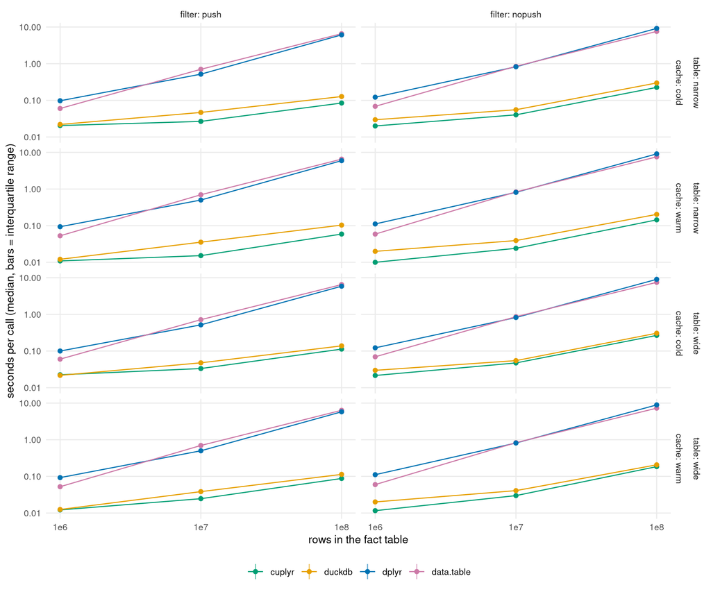

Pipeline p1: filter, mutate, group by store and channel, summarise (4000 groups)

### Pipeline `p2`

filter, mutate, join to the store dimension, group by region and channel, summarise (40 groups). Warm cache:

| filter | table | rows | cuplyr | duckdb | dplyr | data.table |
| --- | --- | --- | --- | --- | --- | --- |
| push | narrow | 1e6 | 0.0143 (0.0141-0.0146) n=15 | **0.0113 (0.0112-0.0117) n=15** | 0.0654 (0.0635-0.0704) n=15 | 0.0664 (0.0641-0.0677) n=15 |
| push | narrow | 1e7 | **0.0242 (0.0238-0.0245) n=10** | 0.0331 (0.0322-0.0342) n=10 | 0.614 (0.598-0.622) n=10 | 0.778 (0.748-0.799) n=10 |
| push | narrow | 1e8 | 0.142 (0.14-0.145) n=5 | **0.0785 (0.0766-0.0788) n=5** | 7.56 (7.55-7.59) n=5 | 7.35 (7.34-7.37) n=5 |
| push | wide | 1e6 | 0.016 (0.0158-0.0171) n=15 | **0.0116 (0.0115-0.0121) n=15** | 0.069 (0.0645-0.0701) n=15 | 0.0633 (0.0626-0.0668) n=15 |
| push | wide | 1e7 | **0.0306 (0.0303-0.031) n=10** | 0.0339 (0.033-0.0347) n=10 | 0.61 (0.603-0.615) n=10 | 0.772 (0.738-0.794) n=10 |
| push | wide | 1e8 | 0.171 (0.169-0.175) n=5 | **0.087 (0.0855-0.0874) n=5** | 7.43 (7.4-7.51) n=5 | 7.04 (6.98-7.16) n=5 |
| nopush | narrow | 1e6 | **0.0148 (0.0146-0.015) n=15** | 0.0199 (0.0196-0.02) n=15 | 0.0967 (0.0951-0.103) n=15 | 0.0693 (0.067-0.0701) n=15 |
| nopush | narrow | 1e7 | **0.0322 (0.032-0.0324) n=10** | 0.036 (0.0333-0.039) n=10 | 0.924 (0.919-0.926) n=10 | 0.902 (0.889-0.915) n=10 |
| nopush | narrow | 1e8 | 0.228 (0.227-0.235) n=5 | **0.19 (0.189-0.191) n=5** | 10.8 (10.7-10.8) n=5 | 8.22 (8.22-8.25) n=5 |
| nopush | wide | 1e6 | **0.0153 (0.0151-0.0157) n=15** | 0.0199 (0.0198-0.0206) n=15 | 0.0968 (0.0961-0.0991) n=15 | 0.0699 (0.0667-0.0725) n=15 |
| nopush | wide | 1e7 | **0.0394 (0.0389-0.0405) n=10** | 0.0406 (0.0399-0.0415) n=10 | 0.924 (0.916-0.929) n=10 | 0.893 (0.89-0.907) n=10 |
| nopush | wide | 1e8 | 0.271 (0.27-0.281) n=5 | **0.19 (0.189-0.19) n=5** | 10.5 (10.4-10.6) n=5 | 7.95 (7.95-8.06) n=5 |

Cold cache:

| filter | table | rows | cuplyr | duckdb | dplyr | data.table |
| --- | --- | --- | --- | --- | --- | --- |
| push | narrow | 1e6 | 0.0243 (0.0242-0.0247) n=15 | **0.0217 (0.0215-0.0222) n=15** | 0.0792 (0.075-0.0815) n=15 | 0.0756 (0.073-0.0768) n=15 |
| push | narrow | 1e7 | **0.035 (0.0346-0.0354) n=10** | 0.0442 (0.0428-0.0455) n=10 | 0.63 (0.628-0.635) n=10 | 0.79 (0.762-0.809) n=10 |
| push | narrow | 1e8 | 0.163 (0.163-0.173) n=5 | **0.105 (0.105-0.106) n=5** | 7.7 (7.62-7.81) n=5 | 7.31 (7.3-7.33) n=5 |
| push | wide | 1e6 | 0.0263 (0.026-0.0271) n=15 | **0.0217 (0.0217-0.0224) n=15** | 0.0777 (0.0749-0.0808) n=15 | 0.0753 (0.0726-0.0766) n=15 |
| push | wide | 1e7 | **0.042 (0.0418-0.0423) n=10** | 0.0439 (0.0437-0.0442) n=10 | 0.643 (0.638-0.652) n=10 | 0.799 (0.775-0.827) n=10 |
| push | wide | 1e8 | 0.195 (0.195-0.203) n=5 | **0.113 (0.112-0.114) n=5** | 7.54 (7.54-7.57) n=5 | 7.17 (7.16-7.24) n=5 |
| nopush | narrow | 1e6 | **0.0236 (0.0233-0.0242) n=15** | 0.0297 (0.0294-0.0298) n=15 | 0.107 (0.107-0.11) n=15 | 0.0771 (0.0754-0.0788) n=15 |
| nopush | narrow | 1e7 | **0.0503 (0.0493-0.0515) n=10** | 0.052 (0.0515-0.0547) n=10 | 0.937 (0.932-0.949) n=10 | 0.916 (0.909-0.931) n=10 |
| nopush | narrow | 1e8 | 0.316 (0.308-0.317) n=5 | **0.279 (0.275-0.281) n=5** | 10.7 (10.7-10.7) n=5 | 8.25 (8.19-8.28) n=5 |
| nopush | wide | 1e6 | **0.0255 (0.0248-0.0261) n=15** | 0.0298 (0.0294-0.0301) n=15 | 0.108 (0.107-0.11) n=15 | 0.0777 (0.0764-0.0808) n=15 |
| nopush | wide | 1e7 | 0.0574 (0.0569-0.0581) n=10 | **0.0538 (0.053-0.0558) n=10** | 0.957 (0.954-0.959) n=10 | 0.932 (0.929-0.939) n=10 |
| nopush | wide | 1e8 | 0.349 (0.348-0.359) n=5 | **0.286 (0.286-0.288) n=5** | 10.5 (10.5-10.8) n=5 | 8.09 (8.09-8.1) n=5 |

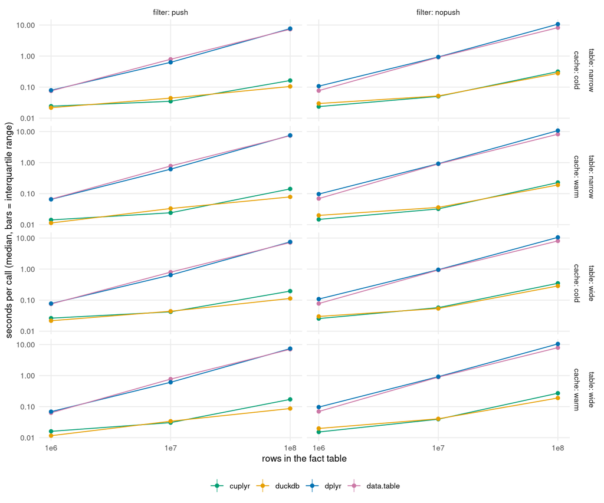

Pipeline p2: filter, mutate, join to the store dimension, group by region and channel, summarise (40 groups)

### Pipeline `p3`

filter, mutate, group by product, sum the revenue, keep the top 10 (ties kept). Warm cache:

| filter | table | rows | cuplyr | duckdb | dplyr | data.table |
| --- | --- | --- | --- | --- | --- | --- |
| push | narrow | 1e6 | **0.00971 (0.00943-0.0111) n=15** | 0.0203 (0.0196-0.0216) n=15 | 0.297 (0.295-0.302) n=15 | 0.0255 (0.0229-0.0256) n=15 |
| push | narrow | 1e7 | **0.0133 (0.0133-0.0136) n=10** | 0.0475 (0.0457-0.0618) n=10 | 0.545 (0.53-0.55) n=10 | 0.317 (0.315-0.369) n=10 |
| push | narrow | 1e8 | **0.0486 (0.0475-0.0508) n=5** | 0.209 (0.208-0.212) n=5 | 2.86 (2.86-2.9) n=5 | 1.76 (1.76-1.8) n=5 |
| push | wide | 1e6 | **0.0107 (0.0105-0.013) n=15** | 0.0212 (0.0199-0.0216) n=15 | 0.294 (0.292-0.302) n=15 | 0.0234 (0.0225-0.0249) n=15 |
| push | wide | 1e7 | **0.0199 (0.0195-0.0202) n=10** | 0.0474 (0.0465-0.0496) n=10 | 0.547 (0.534-0.557) n=10 | 0.321 (0.314-0.368) n=10 |
| push | wide | 1e8 | **0.0792 (0.0778-0.0803) n=5** | 0.216 (0.213-0.219) n=5 | 2.85 (2.85-2.88) n=5 | 1.75 (1.74-1.77) n=5 |
| nopush | narrow | 1e6 | **0.0101 (0.00988-0.0118) n=15** | 0.0285 (0.0273-0.0305) n=15 | 0.345 (0.342-0.351) n=15 | 0.0626 (0.0612-0.0636) n=15 |
| nopush | narrow | 1e7 | **0.0238 (0.0236-0.0252) n=10** | 0.0557 (0.0538-0.0569) n=10 | 1.03 (1.02-1.05) n=10 | 0.829 (0.824-0.841) n=10 |
| nopush | narrow | 1e8 | **0.158 (0.157-0.167) n=5** | 0.341 (0.341-0.344) n=5 | 8.99 (8.97-9.01) n=5 | 7.52 (7.51-7.52) n=5 |
| nopush | wide | 1e6 | **0.0111 (0.0109-0.0113) n=15** | 0.029 (0.0281-0.0298) n=15 | 0.349 (0.345-0.352) n=15 | 0.0657 (0.0642-0.0659) n=15 |
| nopush | wide | 1e7 | **0.031 (0.0307-0.0332) n=10** | 0.0547 (0.0522-0.0587) n=10 | 1.04 (1.02-1.04) n=10 | 0.836 (0.827-0.844) n=10 |
| nopush | wide | 1e8 | **0.197 (0.193-0.205) n=5** | 0.342 (0.341-0.343) n=5 | 8.7 (8.62-8.73) n=5 | 7.27 (7.26-7.3) n=5 |

Cold cache:

| filter | table | rows | cuplyr | duckdb | dplyr | data.table |
| --- | --- | --- | --- | --- | --- | --- |
| push | narrow | 1e6 | **0.0189 (0.0186-0.0191) n=15** | 0.0298 (0.0296-0.0314) n=15 | 0.31 (0.304-0.315) n=15 | 0.0344 (0.0318-0.0347) n=15 |
| push | narrow | 1e7 | **0.0265 (0.0258-0.027) n=10** | 0.0571 (0.0564-0.0583) n=10 | 0.574 (0.556-0.577) n=10 | 0.344 (0.339-0.388) n=10 |
| push | narrow | 1e8 | **0.0812 (0.0811-0.0817) n=5** | 0.24 (0.237-0.241) n=5 | 3.03 (3.03-3.06) n=5 | 1.92 (1.9-1.93) n=5 |
| push | wide | 1e6 | **0.0209 (0.0206-0.0222) n=15** | 0.0308 (0.0304-0.0319) n=15 | 0.306 (0.303-0.314) n=15 | 0.0349 (0.0333-0.0352) n=15 |
| push | wide | 1e7 | **0.0339 (0.0331-0.0342) n=10** | 0.0609 (0.0595-0.0614) n=10 | 0.58 (0.569-0.587) n=10 | 0.35 (0.344-0.396) n=10 |
| push | wide | 1e8 | **0.119 (0.118-0.12) n=5** | 0.258 (0.256-0.261) n=5 | 3.09 (3.08-3.13) n=5 | 1.94 (1.93-1.99) n=5 |
| nopush | narrow | 1e6 | **0.0196 (0.0193-0.0227) n=15** | 0.038 (0.0373-0.0391) n=15 | 0.356 (0.35-0.359) n=15 | 0.0726 (0.0701-0.0735) n=15 |
| nopush | narrow | 1e7 | **0.0445 (0.0443-0.0451) n=10** | 0.0704 (0.0681-0.073) n=10 | 1.05 (1.04-1.06) n=10 | 0.85 (0.846-0.857) n=10 |
| nopush | narrow | 1e8 | **0.282 (0.279-0.286) n=5** | 0.455 (0.452-0.456) n=5 | 9.05 (9.02-9.07) n=5 | 7.53 (7.51-7.57) n=5 |
| nopush | wide | 1e6 | **0.0216 (0.0214-0.0223) n=15** | 0.0378 (0.0369-0.0389) n=15 | 0.359 (0.353-0.361) n=15 | 0.072 (0.0714-0.0725) n=15 |
| nopush | wide | 1e7 | **0.055 (0.0547-0.0559) n=10** | 0.075 (0.0713-0.0772) n=10 | 1.06 (1.04-1.08) n=10 | 0.864 (0.858-0.872) n=10 |
| nopush | wide | 1e8 | **0.355 (0.348-0.362) n=5** | 0.522 (0.486-0.526) n=5 | 9.1 (9.05-9.2) n=5 | 7.49 (7.46-7.51) n=5 |

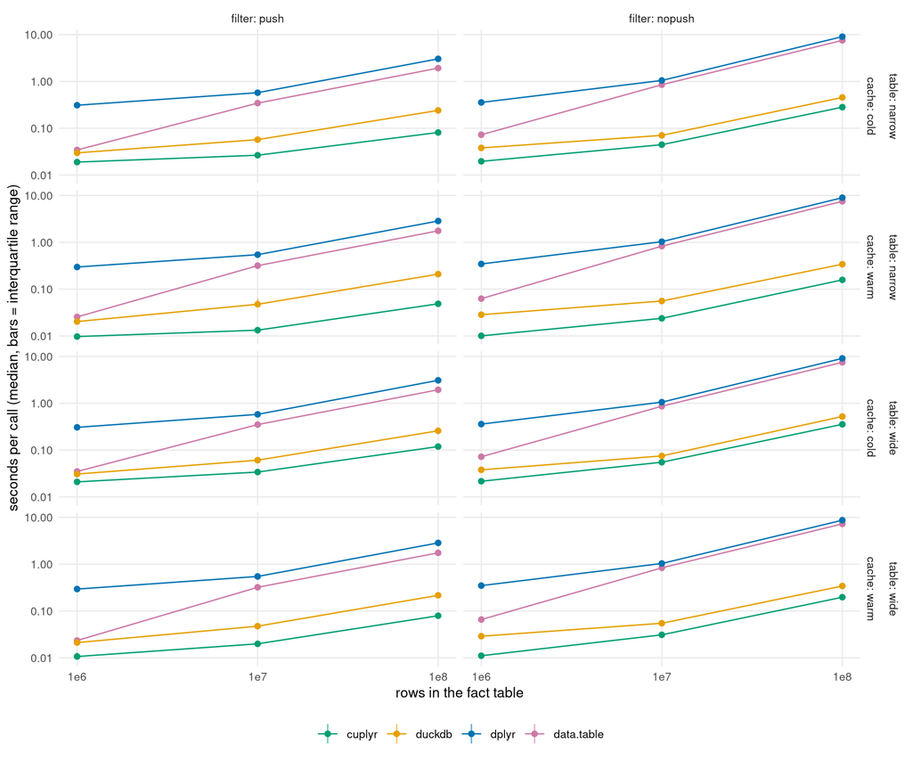

Pipeline p3: filter, mutate, group by product, sum the revenue, keep the top 10 (ties kept)

## Where cuplyr wins and loses

### Overall

cuplyr has the lowest median in 58 of the 72 cells where it and another engine both have quiet reps (30 of 36 warm, 28 of 36 cold). cuplyr’s median is 0.23 to 1.97 times the fastest other engine’s, over the cells where cuplyr and at least one other engine have quiet reps. There is no combination of size, cache state and filter in which cuplyr has the lowest median in fewer than half of its cells. In the cells it loses, the fastest engine is duckdb (14). By pipeline, the cells in which cuplyr is not the fastest are p1 (1 of its 24 cells) and p2 (13 of its 24 cells). With the pushed filter at 1e8 rows (narrow table, warm cache), the join pipeline p2 takes 2.4 times the time of p1 in cuplyr and 0.8 times in DuckDB.

| rows | cache | filter | cells | cuplyr fastest | median ratio to the best other | worst ratio |
| --- | --- | --- | --- | --- | --- | --- |
| 1e6 | cold | push | 6 | 3 | 0.99 | 1.21 |
| 1e6 | cold | nopush | 6 | 6 | 0.70 | 0.85 |
| 1e6 | warm | push | 6 | 4 | 0.94 | 1.38 |
| 1e6 | warm | nopush | 6 | 6 | 0.54 | 0.77 |
| 1e7 | cold | push | 6 | 6 | 0.63 | 0.96 |
| 1e7 | cold | nopush | 6 | 5 | 0.80 | 1.07 |
| 1e7 | warm | push | 6 | 6 | 0.54 | 0.90 |
| 1e7 | warm | nopush | 6 | 6 | 0.67 | 0.97 |
| 1e8 | cold | push | 6 | 4 | 0.74 | 1.72 |
| 1e8 | cold | nopush | 6 | 4 | 0.81 | 1.22 |
| 1e8 | warm | push | 6 | 4 | 0.67 | 1.97 |
| 1e8 | warm | nopush | 6 | 4 | 0.80 | 1.43 |

### What cuplyr’s time is spent on

The results are small (at most 4000 rows). To see how cuplyr’s time divides, the `probe` step ran four separate calls for the two variants of the first pipeline at 1e7 and 1e8 rows (narrow table, warm cache, the same quiet-machine rule as above): the scan alone (the lazy `read_parquet_gpu` read, the pushed filter if the variant has one, and the needed columns, computed into a GPU table), the whole plan computed into a GPU table, a `collect()` of a table that was computed beforehand (the transfer to R), and the benchmark’s whole call. Each stage ends with `gpu_sync()`, so queued GPU work is counted in the stage that queued it. The stages are separate calls, so their times do not add up exactly; the shares are relative to the whole call. They are steady-state calls, after an untimed run of the plan, so they leave out the start-up cost of a first call (see the first-call section). 3 of the 123 probe calls were not quiet and are left out.

| rows | variant | scan | plan to a GPU table | collect of a computed table | whole call | scan share | collect share |
| --- | --- | --- | --- | --- | --- | --- | --- |
| 1e7 | p1_nopush | 0.0165 s | 0.0224 s | 0.000598 s | 0.0228 s | 72% | 2.6% |
| 1e7 | p1_push | 0.0109 s | 0.0144 s | 0.000655 s | 0.0148 s | 73% | 4.4% |
| 1e8 | p1_nopush | 0.11 s | 0.142 s | 0.00044 s | 0.141 s | 78% | 0.3% |
| 1e8 | p1_push | 0.0406 s | 0.0541 s | 0.000515 s | 0.0539 s | 75% | 1.0% |

At 1e8 rows (warm cache, narrow table), the scan alone takes 75% to 78% of the whole call in the two first-pipeline variants, the rest of the plan (filter, mutate, aggregate) 23% to 25%, and collecting a result that is already computed takes 0.3% to 1.0%. So, in these calls, bringing the answer to R is a small part of cuplyr’s time, and the scan (reading and decoding the file) is the largest part of it.

### Pushdown

| variant | table | rows | read | columns read | row groups kept | rows decoded | rows returned | pushed |
| --- | --- | --- | --- | --- | --- | --- | --- | --- |
| p1_nopush | narrow | 1e6 | whole pipeline | 5 of 8 | all 1 | 100% | 100% | none |
| p1_nopush | narrow | 1e7 | whole pipeline | 5 of 8 | all 10 | 100% | 100% | none |
| p1_nopush | narrow | 1e8 | whole pipeline | 5 of 8 | all 96 | 100% | 100% | none |
| p1_nopush | wide | 1e6 | whole pipeline | 5 of 40 | all 1 | 100% | 100% | none |
| p1_nopush | wide | 1e7 | whole pipeline | 5 of 40 | all 10 | 100% | 100% | none |
| p1_nopush | wide | 1e8 | whole pipeline | 5 of 40 | all 96 | 100% | 100% | none |
| p1_push | narrow | 1e6 | whole pipeline | 6 of 8 | 1 of 1 | 100% | 19% | day >= 2024-01-01 & qty >= 2 |
| p1_push | narrow | 1e7 | whole pipeline | 6 of 8 | 3 of 10 | 27% | 19% | day >= 2024-01-01 & qty >= 2 |
| p1_push | narrow | 1e8 | whole pipeline | 6 of 8 | 20 of 96 | 20% | 19% | day >= 2024-01-01 & qty >= 2 |
| p1_push | wide | 1e6 | whole pipeline | 6 of 40 | 1 of 1 | 100% | 19% | day >= 2024-01-01 & qty >= 2 |
| p1_push | wide | 1e7 | whole pipeline | 6 of 40 | 3 of 10 | 27% | 19% | day >= 2024-01-01 & qty >= 2 |
| p1_push | wide | 1e8 | whole pipeline | 6 of 40 | 20 of 96 | 20% | 19% | day >= 2024-01-01 & qty >= 2 |
| p2_nopush | narrow | 1e6 | fact side alone | 5 of 8 | all 1 | 100% | 100% | none |
| p2_nopush | narrow | 1e7 | fact side alone | 5 of 8 | all 10 | 100% | 100% | none |
| p2_nopush | narrow | 1e8 | fact side alone | 5 of 8 | all 96 | 100% | 100% | none |
| p2_nopush | wide | 1e6 | fact side alone | 5 of 40 | all 1 | 100% | 100% | none |
| p2_nopush | wide | 1e7 | fact side alone | 5 of 40 | all 10 | 100% | 100% | none |
| p2_nopush | wide | 1e8 | fact side alone | 5 of 40 | all 96 | 100% | 100% | none |
| p2_push | narrow | 1e6 | fact side alone | 6 of 8 | 1 of 1 | 100% | 19% | day >= 2024-01-01 & qty >= 2 |
| p2_push | narrow | 1e7 | fact side alone | 6 of 8 | 3 of 10 | 27% | 19% | day >= 2024-01-01 & qty >= 2 |
| p2_push | narrow | 1e8 | fact side alone | 6 of 8 | 20 of 96 | 20% | 19% | day >= 2024-01-01 & qty >= 2 |
| p2_push | wide | 1e6 | fact side alone | 6 of 40 | 1 of 1 | 100% | 19% | day >= 2024-01-01 & qty >= 2 |
| p2_push | wide | 1e7 | fact side alone | 6 of 40 | 3 of 10 | 27% | 19% | day >= 2024-01-01 & qty >= 2 |
| p2_push | wide | 1e8 | fact side alone | 6 of 40 | 20 of 96 | 20% | 19% | day >= 2024-01-01 & qty >= 2 |
| p3_nopush | narrow | 1e6 | whole pipeline | 5 of 8 | all 1 | 100% | 100% | none |
| p3_nopush | narrow | 1e7 | whole pipeline | 5 of 8 | all 10 | 100% | 100% | none |
| p3_nopush | narrow | 1e8 | whole pipeline | 5 of 8 | all 96 | 100% | 100% | none |
| p3_nopush | wide | 1e6 | whole pipeline | 5 of 40 | all 1 | 100% | 100% | none |
| p3_nopush | wide | 1e7 | whole pipeline | 5 of 40 | all 10 | 100% | 100% | none |
| p3_nopush | wide | 1e8 | whole pipeline | 5 of 40 | all 96 | 100% | 100% | none |
| p3_push | narrow | 1e6 | whole pipeline | 5 of 8 | 1 of 1 | 100% | 19% | day >= 2024-01-01 & qty >= 2 |
| p3_push | narrow | 1e7 | whole pipeline | 5 of 8 | 3 of 10 | 27% | 19% | day >= 2024-01-01 & qty >= 2 |
| p3_push | narrow | 1e8 | whole pipeline | 5 of 8 | 20 of 96 | 20% | 19% | day >= 2024-01-01 & qty >= 2 |
| p3_push | wide | 1e6 | whole pipeline | 5 of 40 | 1 of 1 | 100% | 19% | day >= 2024-01-01 & qty >= 2 |
| p3_push | wide | 1e7 | whole pipeline | 5 of 40 | 3 of 10 | 27% | 19% | day >= 2024-01-01 & qty >= 2 |
| p3_push | wide | 1e8 | whole pipeline | 5 of 40 | 20 of 96 | 20% | 19% | day >= 2024-01-01 & qty >= 2 |

The table is what `parquet_last_read()` reported after each cuplyr check run of the fact file. For the join pipeline the last read of the whole pipeline is the dimension file, so its rows are from a run of the fact side alone (the scan, the filter and the new column). **Rows decoded** is the rows in the row groups kept after the statistics, from the file’s metadata: the reader decodes whole row groups. **Rows returned** is what the scan hands on, after the pushed filter. Both filters keep about the same share of the rows (19% and 19%), but the pushed filter is not the same work as the other one: dplyr and data.table push nothing and read every row, and their time for the pushed variant is 0.62 to 0.9 times that of the other, over the sizes in the table below. So the filters differ in cost on their own, and the gap in cuplyr’s time cannot be put down to the pushdown alone. Where the pushed filter skips no row group (1e6 rows: the file has a single row group), cuplyr’s ratio is 1.09. Where it skips row groups (3 of 10 kept at 1e7 rows and 20 of 96 kept at 1e8 rows), cuplyr’s ratio is 0.63 and 0.41. It is lower than both CPU engines’ ratios at 1e8 rows and not at 1e7 rows. Where it is lower, skipping row groups may be adding to the filters’ own cost difference; this table does not separate the two. DuckDB’s ratio at 1e8 rows is lower than the CPU engines’ too (0.51), which fits it using row group statistics as well (not checked here).

| rows | row groups kept | rows decoded | cuplyr | duckdb | dplyr | data.table |
| --- | --- | --- | --- | --- | --- | --- |
| 1e6 | 1 of 1 | 100% | 1.09 | 0.61 | 0.84 | 0.90 |
| 1e7 | 3 of 10 | 27% | 0.63 | 0.90 | 0.62 | 0.84 |
| 1e8 | 20 of 96 | 20% | 0.41 | 0.51 | 0.65 | 0.87 |

The last four columns are the median time of the pushed variant divided by that of the other variant of the first pipeline (narrow table, warm cache).

### Why cuplyr loses the join pipeline

The join pipeline accounts for 13 of cuplyr’s 14 lost cells. On inputs already on the device at 1e8 rows, cuplyr’s join of the filtered facts to the dimension takes 0.0807 s (pushed filter) and 0.0796 s (other filter), which is 8.6 and 7.9 times its aggregate of the same rows (0.0094 s and 0.0101 s), and 90% and 90% of its join and aggregate together. With the pushed filter, cuplyr’s join alone is 1.2 times faster than DuckDB’s join into a table, while DuckDB’s join and aggregate in one query (0.0374 s) is 2.4 times faster than cuplyr’s (0.0898 s). In the benchmark itself the join pipeline takes 0.0828 s (pushed filter) and 0.0837 s (other filter) longer than the first pipeline in cuplyr at 1e8 rows (narrow table, warm cache), close to the join’s time here. The fact scan of the join pipeline with the pushed filter keeps 20 of 96 row groups, as in the first pipeline, so the pushdown survives the join. The probe shows where the time goes (the join, not the scan or the aggregate); it does not show why the join takes that long. 0 of the probe’s calls were not quiet and are left out.

| rows | variant | cuplyr join | cuplyr aggregate | cuplyr join and aggregate | DuckDB join | DuckDB aggregate | DuckDB join and aggregate |
| --- | --- | --- | --- | --- | --- | --- | --- |
| 1e7 | p2_push | 0.00753 s | 0.0037 s | 0.0108 s | 0.0168 s | 0.0147 s | 0.0108 s |
| 1e7 | p2_nopush | 0.00752 s | 0.00356 s | 0.0106 s | 0.0215 s | 0.0108 s | 0.0104 s |
| 1e8 | p2_push | 0.0807 s | 0.0094 s | 0.0898 s | 0.0967 s | 0.0404 s | 0.0374 s |
| 1e8 | p2_nopush | 0.0796 s | 0.0101 s | 0.0882 s | 0.1 s | 0.0406 s | 0.0365 s |

The inputs of the probe are the filtered fact columns as a table on the device (cuplyr) or as a temporary table (DuckDB), and the dimension; the aggregate is the first pipeline’s. DuckDB’s “join” creates a table of the joined rows, which cuplyr’s “join” also computes. A repro for the join is under Findings.

### Projection on the wide table

At 1e8 rows with the nopush filter and a warm cache, the wide table has 40 columns against 8; every engine is asked for the same 5 columns. cuplyr is 1.28 times slower on the wide table, duckdb does not slow down on the wide table, dplyr does not slow down on the wide table and data.table does not slow down on the wide table. cuplyr reads 5 of the 40 columns of the wide file (see the table above), and DuckDB and arrow are given the same column list.

### Cold cache

At 1e8 rows (narrow table, nopush filter, first pipeline) the cold call takes 1.56 times the warm call for cuplyr, 1.46 times the warm call for duckdb, 1.01 times the warm call for dplyr and 1.01 times the warm call for data.table.

### The first call of a cell

Within a cell, the first call (rep 0, after the warm-up, not in the medians) takes this multiple of the cell’s median (median over cells): cuplyr 0.99, duckdb 0.99, dplyr 1.01 and data.table 1.03. The fresh-process first calls are in the next section.

### Memory

No cell ran out of memory.

## First call

Each engine and variant ran in a fresh R process at 1e7 rows (narrow table, warm cache): the packages were loaded first (`load_secs`; for cuplyr that is `pkgload::load_all()` of the checkout, which is not what an installed package would pay), DuckDB’s connection was opened, and then the calls ran one after another, each timed separately. A call is slow when it takes more than three times the median of the later half of the calls.

| engine | call 1 | call 2 | call 3 | call 4 | call 5 | call 6 | call 7 | call 8 | load (s) |
| --- | --- | --- | --- | --- | --- | --- | --- | --- | --- |
| cuplyr | 0.715 | 0.66 | 0.0151 | 0.0147 | 0.0145 | 0.0142 | 0.0143 | 0.0143 | 0.676 |
| duckdb | 0.0355 | 0.0396 | 0.0372 | 0.0345 | 0.0364 | 0.0347 | 0.0349 | 0.0401 | 0.151 |
| dplyr | 0.652 | 0.531 | 0.516 | 0.547 | 0.502 | 0.505 | 0.503 | 0.501 | 0.243 |
| data.table | 0.748 | 0.521 | 0.534 | 0.516 | 0.565 | 0.518 | 0.534 | 0.524 | 0.186 |

| engine | variants with a slow start | slow calls (median) | first call, median (s) | later calls, median (s) |
| --- | --- | --- | --- | --- |
| cuplyr | 6 | 2 | 0.715 | 0.022 |
| duckdb | 0 | 0 | 0.0403 | 0.037 |
| dplyr | 0 | 0 | 0.84 | 0.732 |
| data.table | 0 | 0 | 0.804 | 0.593 |

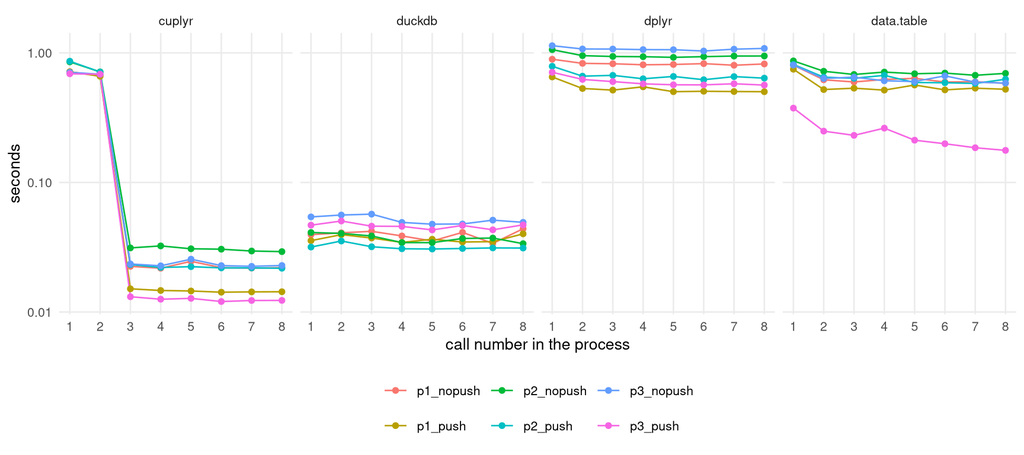

Seconds per call in a fresh process, by call number and variant

### New pipeline shapes in a warm process

The first-call finding is not confined to a process’s first calls, and the shapes probe shows it. The shapes are `scan` (read one column and collect it), `filter_int` (an integer filter on the whole file), `filter_date_int` (the pushed Date and integer filter), `summarise` (a grouped count), `mutate_sum` (a new column and its sum) and `p1_push` (the first pipeline). The probe repeats small cuplyr pipelines in fresh processes (6 shapes, each alone for 5 calls, then all in one process in order for 4 calls each; the file has 1e7 rows). A call is slow when it takes more than three times the shape’s fastest call in the probe. Alone, the first two calls are slow in 6 of the 6 shapes, and the first call takes 16 to 58 times the fastest. This includes the smallest shape (`scan`: read one column and collect it), which has 4 slow calls. In the sequence, 5 of the 5 shapes after the first have a slow call among their first two, up to 35 times their fastest call. So a new pipeline shape in an already warm process can be slow for its first calls, and the cost is not paid once per process.

Each shape in a fresh process of its own (seconds per call):

| shape | call 1 | call 2 | call 3 | call 4 | call 5 |
| --- | --- | --- | --- | --- | --- |
| scan | 0.226 | 0.234 | 0.0638 | 0.0627 | 0.0137 |
| filter_int | 0.478 | 0.471 | 0.0746 | 0.0704 | 0.0716 |
| filter_date_int | 0.533 | 0.308 | 0.0202 | 0.00989 | 0.0108 |
| summarise | 0.355 | 0.446 | 0.0095 | 0.00877 | 0.00884 |
| mutate_sum | 0.425 | 0.453 | 0.012 | 0.0117 | 0.0115 |
| p1_push | 0.708 | 0.661 | 0.0146 | 0.0139 | 0.0137 |

All shapes in one process, in this order (seconds per call):

| shape | call 1 | call 2 | call 3 | call 4 |
| --- | --- | --- | --- | --- |
| scan | 0.218 | 0.234 | 0.063 | 0.0586 |
| filter_int | 0.216 | 0.364 | 0.0238 | 0.0258 |
| filter_date_int | 0.017 | 0.0314 | 0.00925 | 0.00938 |
| summarise | 0.0909 | 0.274 | 0.00835 | 0.00786 |
| mutate_sum | 0.0238 | 0.15 | 0.0124 | 0.0116 |
| p1_push | 0.0498 | 0.0599 | 0.0139 | 0.0137 |

## Findings

### cuplyr’s slow first calls of each new pipeline shape

In a fresh process the first 2 calls of cuplyr’s pipeline `p1_push` at 1e7 rows take about 0.688 s each (the first takes 0.715 s, the second 0.66 s, the third 0.0151 s), and the later calls about 0.0143 s. The slowness appears in 6 of the 6 cuplyr variants, with a median of 2 slow calls per variant. The shapes probe (in the first-call section) finds the pattern beyond the full pipeline: alone, 6 of 6 shapes have two slow first calls, and in one process, 5 of the 5 shapes after the first have a slow call among their first two.

The smallest repro found, in a fresh R process (the file is the benchmark’s narrow table at 1e7 rows from `pp_gen_fact()`; the probe’s calls took 0.226 s, 0.234 s, 0.0638 s, 0.0627 s and 0.0137 s, in this order):

```r
pkgload::load_all("."); library(dplyr)
f <- "fact-narrow-10000000.parquet"
for (i in 1:5) print(system.time(collect(read_parquet_gpu(f, columns = "store")))[["elapsed"]])
```

What the extra time is spent on is not examined here.

### The join of the second pipeline

On inputs already on the device at 1e8 rows, cuplyr’s join of the filtered facts to the dimension takes 0.0807 s (pushed filter) and 0.0796 s (other filter), which is 8.6 and 7.9 times its aggregate of the same rows (0.0094 s and 0.0101 s), and 90% and 90% of its join and aggregate together. With the pushed filter, cuplyr’s join alone is 1.2 times faster than DuckDB’s join into a table, while DuckDB’s join and aggregate in one query (0.0374 s) is 2.4 times faster than cuplyr’s (0.0898 s). In the benchmark itself the join pipeline takes 0.0828 s (pushed filter) and 0.0837 s (other filter) longer than the first pipeline in cuplyr at 1e8 rows (narrow table, warm cache), close to the join’s time here. The fact scan of the join pipeline with the pushed filter keeps 20 of 96 row groups, as in the first pipeline, so the pushdown survives the join. The probe shows where the time goes (the join, not the scan or the aggregate); it does not show why the join takes that long.

A repro of the join alone, on inputs that are already on the device (`stores.parquet` is the dimension from `pp_gen_dim()`; run it in a process that has already run the plan a few times, so that the first-call cost is out of it):

```r
pkgload::load_all("."); library(dplyr)
f <- "fact-narrow-100000000.parquet"
x <- read_parquet_gpu(f) |>
  filter(day >= as.Date("2024-01-01"), qty >= 2L) |>
  mutate(revenue = price * qty * (1 - discount)) |>
  select(store, channel, price, qty, revenue) |>
  compute()
d <- compute(read_parquet_gpu("stores.parquet"))
for (i in 1:5) print(system.time({ j <- compute(inner_join(x, d, by = "store")); cuplyr::gpu_sync() })[["elapsed"]])
```

### Wrong results and errors

None: every engine matched the reference in every cell.

### Memory

No cell ran out of memory. In cuplyr this is a classed `cuplyr_error_gpu_oom` error; it is recorded as “does not fit”, not retried.

## Caveats

- cuplyr runs with libcudf’s debug stream pool switched on, which its `.onLoad` does by default since the second attempt at F85 (`LIBCUDF_USE_DEBUG_STREAM_POOL`, read back as set (1)). Every cuplyr number here includes that setting.
- F128 (the memory resource), F86 (transfers) and F87 (chunked streaming) may change cuplyr’s numbers; this is a first set of measurements, to be repeated after they land.
- Other jobs on the machine. F123 was expected to share the machine with this benchmark; the lock log shows whether it did. The lock log lists the GPU jobs of every worktree. 15 of the 15 timing windows (the readers, time, first and probe steps of `provenance.csv`) lie inside one lock hold of F121. Jobs of other worktrees held the lock for at most 0.7 seconds inside a window (the log’s resolution is one second), and 0 of them overlapped by more than that. 9 jobs of other worktrees (F124: 9) were queued while the windows were open. F123 has 0 jobs in the log during the windows. Work outside the lock (compiles, `tools/build`) is not in the log; it would show as foreign load, which the quiet-machine rule bounds.
- Process effects. Each engine’s median time in the shared timing process at 1e7 rows (narrow table, warm cache, over the variants), relative to its median over calls 2 to 8 in a fresh process of its own: cuplyr 1.05, duckdb 1.00, dplyr 0.98 and data.table 1.35. data.table’s numbers in the tables above are therefore likely higher than they would be in a process of its own; the data do not show why. data.table is the fastest other engine in no cell, so no win or loss of cuplyr depends on its numbers.
- The first call. The tables are medians of warm-process calls after an untimed warm-up. In a fresh process, cuplyr’s first call takes 0.715 s and its later calls 0.022 s (median over the variants), and each new pipeline shape repeats part of that (see the first-call section); a script that runs each pipeline once is not what the tables measure.
- The data are sorted by date, which favours date pruning for any engine that uses row group statistics. Unsorted data would show less of the pushdown gap.
- DuckDB’s local file caching is off by default (`cache_local_files` read back as FALSE), so for DuckDB warm and cold mean the operating system’s page cache, as for the others.
- One machine, one GPU, synthetic data, one codec (snappy), and the default thread counts of every engine; other settings or hardware will move the ratios.